# financial_analysis_project_milestone_1

## Financial Analysis Project

## Collaboration Plan:

Raymond and I plan to meet twice a week to stay on track with our weekly goals. Every Monday, we will discuss what we want to accomplish *that* week and divide the tasks accordingly. We will meet again on Thursday to review progress, address any roadblocks, and plan any additional work required for the weekend. If necessary, we will also meet on Sunday to resolve any remaining issues together.

## Project Description:

In this project, we will analyze Apple Inc.'s stock prices using Monte Carlo simulations to predict future price behavior. Our primary objective is to explore the volatility of stock prices and gain insights into potential future price distributions using daily stock data.

### Research Questions:

- What is the historical volatility of Apple stock prices?
- How can Monte Carlo simulations help predict future price behavior?

## Data Source:

The dataset for this project is sourced from Nasdaq and consists of Apple Inc.'s daily stock prices. The dataset includes the following columns: Date, Adjusted Price, Volume, Open, High, and Low prices. For our analysis, we will primarily focus on the Adjusted Price.

## Summary Statistics Explained

- **Mean Price**: The average adjusted price of Apple stock.
- **Median Price**: The median adjusted price, providing a robust measure of central tendency.
- **Price Standard Deviation**: A measure of price volatility over the period.
- **Minimum and Maximum Price**: The lowest and highest prices in the dataset, giving the range of price movement.
- **Annualized Return**: The average return of the stock over a year.
- **Annualized Volatility**: The volatility of the stock price over a year, important for assessing risk.
- **Skewness**: The asymmetry of daily returns, showing whether returns are more likely to be extreme gains or losses.
- **Kurtosis**: The tailedness of the return distribution, highlighting the likelihood of outliers.
- **Max Drawdown**: The largest peak-to-trough decline, showing the worst-case downside risk.

```python
# Import necessary libraries
import pandas as pd
import numpy as np
import matplotlib.pyplot as plt
from google.colab import files
uploaded = files.upload()

# Ensure plots display inline in the notebook
%matplotlib inline

# Load the CSV file directly
file_path = 'AAPL.csv'
data = pd.read_csv('AAPL.csv')

# Convert the 'Date' column to datetime
data['Date'] = pd.to_datetime(data['Date'])

# Check the structure of the data to ensure the correct columns are present
print(data.columns)
data.head()
```

Upload widget is only available when the cell has been executed in the current browser session. Please rerun this cell to enable.

```
Saving AAPL.csv to AAPL (1).csv
Index(['Date', 'Adjusted Price', 'Open', 'Low', 'High', 'Volume'], dtype='object')
```

|  | Date | Adjusted Price | Open | Low | High | Volume |
| --- | --- | --- | --- | --- | --- | --- |
| 0 | 1988-09-01 | 0.270 | 0.270 | 0.267 | 0.277 | 246736.0 |
| 1 | 1988-09-02 | 0.277 | 0.277 | 0.270 | 0.279 | 186300.8 |
| 2 | 1988-09-06 | 0.270 | 0.270 | 0.269 | 0.279 | 143449.6 |
| 3 | 1988-09-07 | 0.266 | 0.266 | 0.262 | 0.276 | 179110.4 |
| 4 | 1988-09-08 | 0.270 | 0.270 | 0.262 | 0.276 | 207256.0 |

```python
# Function to calculate and display summary statistics
def summary_statistics(data):
    if 'Adjusted Price' not in data.columns:
        raise KeyError("'Adjusted Price' column is missing in the data.")

    # Ensure daily return column exists
    if 'Daily Return' not in data.columns:
        data['Daily Return'] = data['Adjusted Price'].pct_change()

    # Drop NaN values from 'Daily Return'
    data_cleaned = data.dropna(subset=['Daily Return'])

    # Calculate summary statistics
    summary_stats = {
        "Mean Price": data['Adjusted Price'].mean(),
        "Median Price": data['Adjusted Price'].median(),
        "Price Standard Deviation": data['Adjusted Price'].std(),
        "Minimum Price": data['Adjusted Price'].min(),
        "Maximum Price": data['Adjusted Price'].max(),
        "Annualized Return": data_cleaned['Daily Return'].mean() * 252,  # 252 trading days
        "Annualized Volatility": data_cleaned['Daily Return'].std() * np.sqrt(252),
        "Skewness": data_cleaned['Daily Return'].skew(),
        "Kurtosis": data_cleaned['Daily Return'].kurtosis(),
        "Max Drawdown": max_drawdown(data['Adjusted Price'])
    }

    return summary_stats

# Function to calculate the maximum drawdown (peak-to-trough decline)
def max_drawdown(prices):
    running_max = prices.cummax()  # Calculate the running maximum price
    drawdown = (prices - running_max) / running_max  # Calculate the percentage drawdown
    return drawdown.min()  # Return the largest drawdown

# Call the function and print summary statistics
stats = summary_statistics(data)
for stat, value in stats.items():
    print(f"{stat}: {value}")
```

```
Mean Price: 27.23105583644757
Median Price: 2.262
Price Standard Deviation: 51.104290844199525
Minimum Price: 0.098
Maximum Price: 234.55
Annualized Return: 0.2778283503745821
Annualized Volatility: 0.42291299754761136
Skewness: -0.3984390466453507
Kurtosis: 23.9108741077217
Max Drawdown: -0.8178472861085557
```

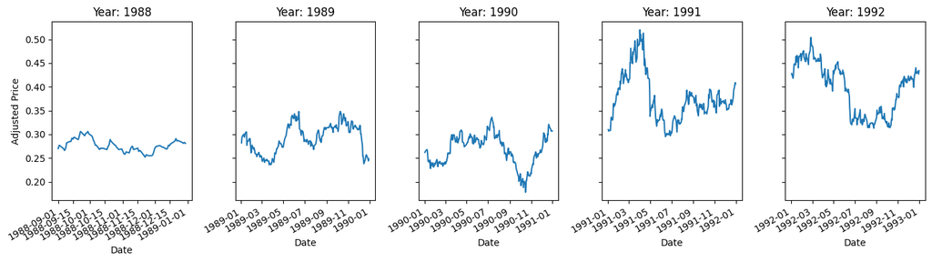

```python
# Convert the 'Date' column to datetime for easy filtering by year
data['Date'] = pd.to_datetime(data['Date'])

# Extract the unique years from the 'Date' column
years = data['Date'].dt.year.unique()

# Create a 1x5 grid for visualizing the adjusted price over 5 different years
fig, axes = plt.subplots(1, len(years[:5]), figsize=(14, 4), sharey=True)  # Adjust number of years if needed

# Loop over each unique year and plot the Adjusted Price for that year
for ax, year in zip(axes, years[:5]):  # Limiting to first 5 years for better visualization
    yearly_data = data[data['Date'].dt.year == year]

    # Plot Adjusted Price over time for that year
    yearly_data.plot(x='Date', y='Adjusted Price', ax=ax, legend=False)

    # Set title and labels
    ax.set_title(f"Year: {year}")
    ax.set_xlabel('Date')
    ax.set_ylabel('Adjusted Price')

# Adjust layout to prevent overlap
plt.tight_layout()
plt.show()
```